# Coursework Report

*N* removed NAs: 2

*N* removed <18: 19

*N* total clean: 127

| Group | *N* | *M*<sub>age</sub> | *M*<sub>rating</sub> |
| --- | --- | --- | --- |
| Control | 62 | 20.69 | 6.54 |
| Experim | 65 | 20.78 | 6.33 |

**Main analysis results**

*t*(125) = 1.68, *p* = .095

# Coursework Report

Analysing Data, Spring 2020

# Methods

## Participants

Table 1 illustrates the statistical properties of the participants involved, including the number of women who took part in either the experimental or control condition, their percentages, as well as their mean ages and standard deviations:

Table 1 *Descriptive Statistics by Condition*

| CONDITION | *N* | % | *M*<sub>age</sub> | *SD*<sub>age</sub> |
| --- | --- | --- | --- | --- |
| control | 62 | 48.82 | 20.69 | 1.99 |
| experimental | 65 | 51.18 | 20.78 | 1.77 |

## Design

In Elliot’s research he examined the effect in which the colour red had on a woman’s perception of a man’s physical attractiveness. Female participants viewed photographs of males who were either placed on a red or white background and were asked to rate the male’s physical attractiveness. The independent variable therefore is the colour the photograph of the man was placed. The experimental condition was those who viewed males with a red background. Whereas, those who viewed males on a white background were the control group, white was used as a control as any other colour may influence one’s attractiveness score. Thus Elliot was able to compare the scores given to each man on the red background compared to the white.

Move over, the dependant variable was the rating of attraction the females gave the photograph of each male. It was decided to measure perceived attractiveness by asking the females the three following questions: “How attractive do you think this person is?”, “How pleasant is this person to look at?” and finally “If I were to meet the person in this picture face to face, I would think he is attractive.” Questions were rated on a nine-point scale, where 1 was “not attractive at all” and 9 was “extremely attractive”, results were then recorded as an average score, available for comparison.

In sum, the operational hypothesis is; the ratings of perceived attractiveness given by the female participants, will be higher for those looking at photographs in the red condition in comparison to the white (control) condition. To test the significance of the results a t-test statistical analysis will be used.

# Results

The results investigated whether, as predicted, the females who took part in the red (experimental) condition would result in giving the males a higher attractiveness score, compared to those in the white (control) condition.

First a composite score was calculated and used as an average. Using the composite score we can conclude, on average, those who took part in the white condition found the males photographed more attractive than those taking part in the red condition (*M*<sub>diff</sub> = 0.21, 95% CI [-0.04, 0.46]). Once the average attractiveness scrore was found, a means plot was created as a visual guide to present the results:

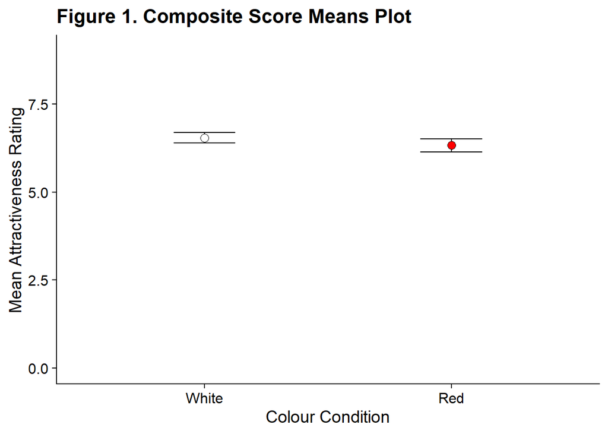

The plot above emphasises the fact there is only a slight difference between the control and experimental group.

To demonstarte this further, a *t*-test was calculated to examine the influence of the colour red on the females attractiveness rating. The results of the t-test (*t* (125) = 1.68, *p* = .095) illustrate there is in fact no significant difference when the males were photographed on top on a red or white background. Furthermore, due to the confidence intervals crossing over zero, it can be assumed the null hypothesis is true. Therefore an acceptance of the null hypothesis and rejection of the experimental hypothesis.

In sum the results highlights women do not perceive men more attractive when in conjunction with the colour red.

# Discussion

From these results, it is clear this experiment has little significance to Elliot’s research on whether the colour red effects one’s perceived attraction. In the original study, participants who viewed male photographs on a red background rated the males significantly more attractive than the males pictured on a white background (Elliot et al., 2010).

Unlike the original study, the results provided above do not support the hypothesis. Instead the control condition of males pictured on a white background had a higher mean attractiveness rating of 6.53, where those pictured on the red background had a lower mean of 6.32. This evokes there is some inconsistency with Elliot’s initial hypothesis. In other words, there is no relationship between males in conjunction with the colour red and a woman’s perceived attraction.

The results, however, are similar to other replications of Elliot’s research. For example, Hesslinger et al’s research in 2015. However, Hesslinger’s research differs slightly to the original, where instead of the standard face photograph of male participants, images of males in a ‘formal style’ and ‘casual style’ were included. As a result, they found a significant effect of apparel style, where those in formal apparel were rated more attractive than in casual style. Yet, no further significance was found for the different colours the males appeared on (Hesslinger et al., 2015). This depicts the results provided above are correct in the fact that red has little influence on a woman’s perceived attraction to males. As an alternative, the results imply women look for other qualities to base their attractiveness ratings on.

Further research to challenge Elliot’s study has been provided by Francis et al, who discovered the original study involved publication bias. The publication bias was a result of null findings being suppressed (Francis, 2013). This is important to include as Elliot’s paper may have misleading judgements and therefore would be difficult for the data above to replicate the findings.

Moreover, research states there is a clear consensus that certain aspects such as apparel in Hesslinger’s study can affect one’s perceived attraction. However, in consideration to the effect of the colour red, there is a lack of empirical evidence to suggest the colour can directly make oneself more attractive. This is supported by Peperkoorn et al who tried to replicate results of the colour in context theory, however, failed to find any supporting evidence (Perperkoorn, 2016).

Finally, the results included above are limited to only using the specific research used by Elliot in only one of his experiments. Instead, this hypothesis may benefit from further research using larger samples, as well as different research approaches. For instance, other aspects could be investigated such as, if a male were to wear red, instead of being photographed on red, would they be perceived more attractive? Furthermore, there has been numerous studies that have found the red effect to be present in males viewing women (Elliot & Niesta, 2008) so alternatively, research could be focused on explaining this gender difference in attractiveness perception.

In summary, the results calculated above challenge the original findings of Elliot’s red effect. This, however, does not imply the results of this experiment should be dismissed, and instead could be used for further research analysis into the colour in context field. It is also imperative to share null findings and therefore these results should not be overlooked. Ultimately, colour is a ubiquitous stimulus therefore research into its effects on one’s emotion and physical preference is endless and should be further analysed.

# References

Elliot, A. J., Niesta Kayser, D., Greitemeyer, T., Lichtenfeld, S., Gramzow, R. H., Maier, M. A., & Liu, H. (2010). Red, rank, and romance in women viewing men. Journal of Experimental Psychology: General, 139(3), 399–417.

Elliot, A. J., & Niesta, D. (2008). Romantic red: Red enhances men’s attraction to women. Journal of Personality and Social Psychology, 95(5), 1150–1164.

Francis, G. (2013). Publication bias in “Red, rank, and romance in women viewing men,” by Elliot et al. (2010). Journal of Experimental Psychology: General, 142(1), 292–296.

Hesslinger, V. M., Goldbach, L., & Carbon, C.-C. (2015). Men in red: A reexamination of the red-attractiveness effect. Psychonomic Bulletin & Review, 22(4), 1142–1148.

Peperkoorn, L. S., Roberts, S. C., & Pollet, T. V. (2016). Revisiting the Red Effect on Attractiveness and Sexual Receptivity: No Effect of the Color Red on Human Mate Preferences. Evolutionary Psychology.